# 3 3. Exploratory Analysis

#### 3.0.0.1 3.1 Correlation Matrix

```r
library(tidyverse)
library(janitor)
library(here)
library(ggplot2)
library(dplyr)
library(GGally)
library(sf)
library(rnaturalearth)
library(rnaturalearthdata)
library(cartogram)
library(plotly)
library(tidyr)
library(scales)
library(patchwork)
library(randomForest)
library(lime)
library(Metrics)
library(iml)       # SHAP
library(mlr3)
library(mlr3learners)
library(ggrepel)
library(grid)   # for unit()
```

```r
combined <- readRDS("data/combined.rds")
corr_data <- combined[, c("temp_anomaly", "co2", "gdp_per_capita",
                          "renewable_energy_share", "methane")]
corr_data <- na.omit(corr_data)
corr_matrix <- cor(corr_data)
corr_matrix
```

```
                       temp_anomaly         co2 gdp_per_capita
temp_anomaly             1.00000000  0.02464909     0.09267985
co2                      0.02464909  1.00000000     0.12959751
gdp_per_capita           0.09267985  0.12959751     1.00000000
renewable_energy_share  -0.03469399 -0.15757929    -0.19358141
methane                  0.00968773  0.87693547     0.12435932
                       renewable_energy_share     methane
temp_anomaly                      -0.03469399  0.00968773
co2                               -0.15757929  0.87693547
gdp_per_capita                    -0.19358141  0.12435932
renewable_energy_share             1.00000000 -0.09812887
methane                           -0.09812887  1.00000000
```

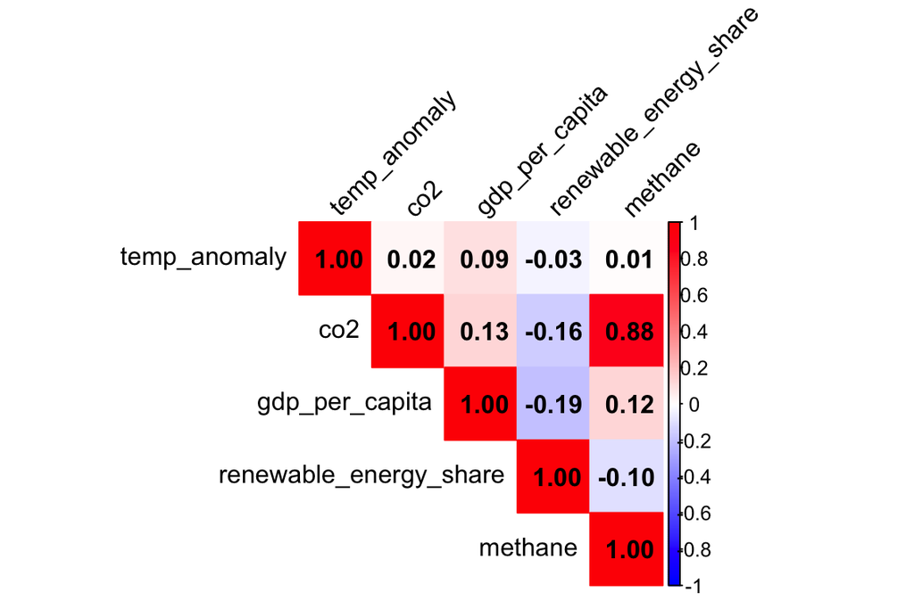

```r
library(corrplot)

corrplot(corr_matrix,
         method="color",
         type="upper",
         addCoef.col="black",
         tl.col="black",
         tl.srt=45,
         col=colorRampPalette(c("blue","white","red"))(200))
```

The correlation matrix provides an initial statistical overview of how key variables—temperature anomaly, CO₂ emissions, GDP per capita, renewable-energy share, and methane—relate to one another. The plot shows very low correlations between temperature anomaly and individual country-level indicators, including CO₂ emissions. This does not mean CO₂ does not drive warming; rather, it reflects that temperature anomalies in the dataset represent global yearly values, while the emissions data represent country-level values, creating a mismatch in granularity. As expected, CO₂ and methane show a very strong positive correlation (≈0.88), consistent with the fact that both gases are released through overlapping industrial and agricultural activities. GDP per capita is weakly correlated with CO₂, suggesting that while richer countries tend to emit more, the relationship is not perfectly linear because some wealthy countries have transitioned to cleaner energy systems. Renewable-energy share displays small negative correlations with GDP and CO₂, implying that countries with stronger renewable penetration tend to have slightly lower emissions intensity. These early correlations help highlight structural relationships and hint at which indicators may contribute more to multivariate patterns later in the analysis.

#### 3.0.0.2 3.2 CO₂ Emissions vs Temperature Anomaly

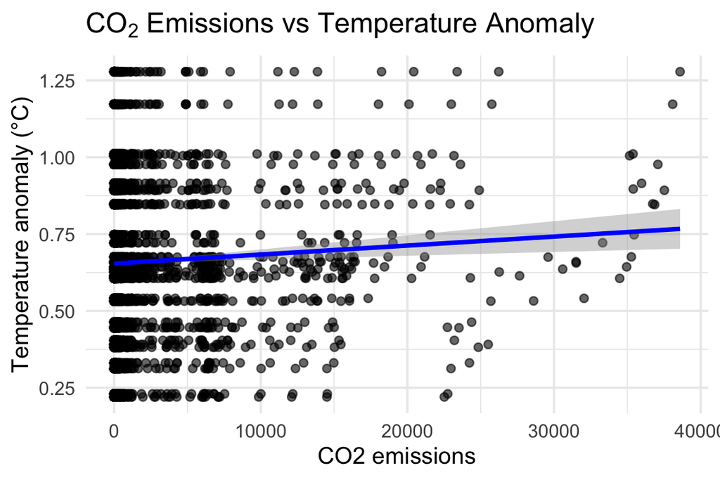

```r
# Filter out NA, Inf, and negative/invalid values

plot_data <- combined[
  is.finite(combined$co2) &
  is.finite(combined$temp_anomaly) &
  combined$co2 >= 0,
]

# plot
ggplot(plot_data, aes(x = co2, y = temp_anomaly)) +
  geom_point(alpha = 0.6) +
  geom_smooth(method = "lm", se = TRUE, color = "blue") +
  labs(
    title = expression(CO[2] * " Emissions vs Temperature Anomaly"),
    x = "CO2 emissions",
    y = "Temperature anomaly (°C)"
  ) +
  theme_minimal(base_size = 14)
```

The scatter plot demonstrates a weak but positive relationship between national CO₂ emissions and global temperature anomalies. Since the temperature anomaly is a global measure applied to all countries for the same year, the pattern largely reflects temporal coincidence: countries emit more CO₂ in years when global temperatures are already trending upward. The fitted regression line shows a slight upward slope, reinforcing the general association that higher global emissions accompany higher global temperatures. Dense clustering near low emissions indicates that many countries contribute minimally to global emissions yet still experience rising global temperatures—a pattern consistent with climate inequality. Meanwhile, the upper-right region of the plot reveals a small group of very high-emitting countries whose individual contributions significantly influence global CO₂ trends.

#### 3.0.0.3 3.3 GDP per Capita vs Renewable-Energy Share

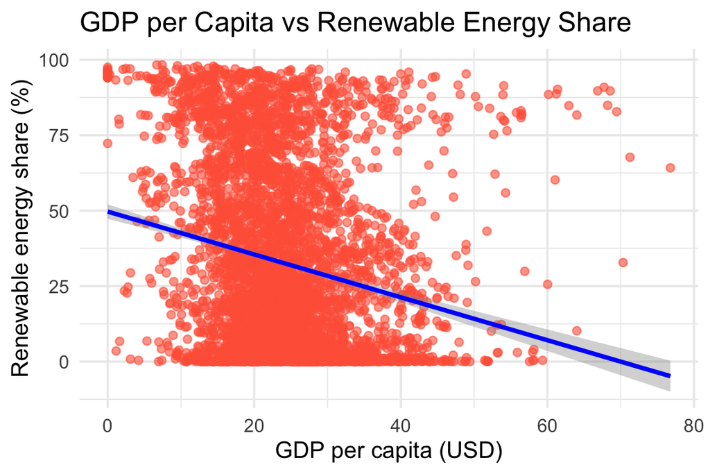

```r
# Clean data: remove NA/Inf, ensure valid values
plot_data2 <- combined[
  is.finite(combined$gdp_per_capita) &
  is.finite(combined$renewable_energy_share) &
  combined$gdp_per_capita >= 0 &
  combined$renewable_energy_share >= 0,
]

# Plot
ggplot(plot_data2, aes(x = gdp_per_capita, y = renewable_energy_share)) +
  geom_point(alpha = 0.6, color = "tomato") +
  geom_smooth(method = "lm", se = TRUE, color = "blue") +
  labs(
    title = "GDP per Capita vs Renewable Energy Share",
    x = "GDP per capita (USD)",
    y = "Renewable energy share (%)"
  ) +
  theme_minimal(base_size = 14)
```

This plot reveals a distinct downward trend, indicating that countries with higher GDP per capita tend to have a lower share of renewable energy consumption. While this may seem counterintuitive—wealthier countries are often viewed as clean-energy leaders—the observed relationship reflects broader global dynamics. Many high-income nations still rely heavily on fossil fuels due to their established industrial systems, energy-intensive lifestyles, and legacy infrastructures. Conversely, some lower-income countries exhibit high renewable-energy shares because their power systems rely on traditional biomass or hydroelectricity rather than complex fossil-fuel networks. The negative slope emphasizes that economic development alone does not guarantee clean energy adoption; rather, structural transitions and policy interventions are required to shift energy portfolios toward low-carbon sources.

#### 3.0.0.4 3.4 Population vs CO₂ Emissions

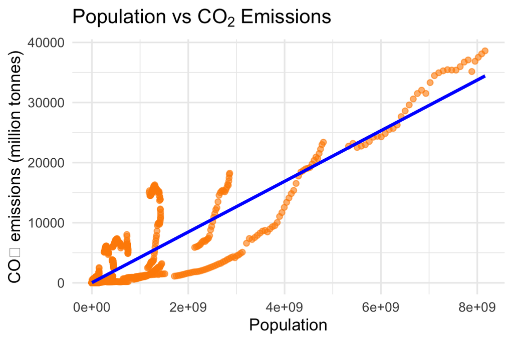

```r
# Clean data using correct population column (base R)
plot_data3 <- combined[
  is.finite(combined$population.x) &
  is.finite(combined$co2) &
  combined$population.x > 0 &
  combined$co2 >= 0,
]

# Plot
ggplot(plot_data3, aes(x = population.x, y = co2)) +
  geom_point(alpha = 0.6, color = "darkorange") +
  geom_smooth(method = "lm", se = TRUE, color = "blue") +
  labs(
    title = expression("Population vs " * CO[2] * " Emissions"),
    x = "Population",
    y = "CO\u2082 emissions (million tonnes)"
  ) +
  theme_minimal(base_size = 14)
```

#### 3.0.0.5 3.5 Acceleration of Global Warming (1990–2023)

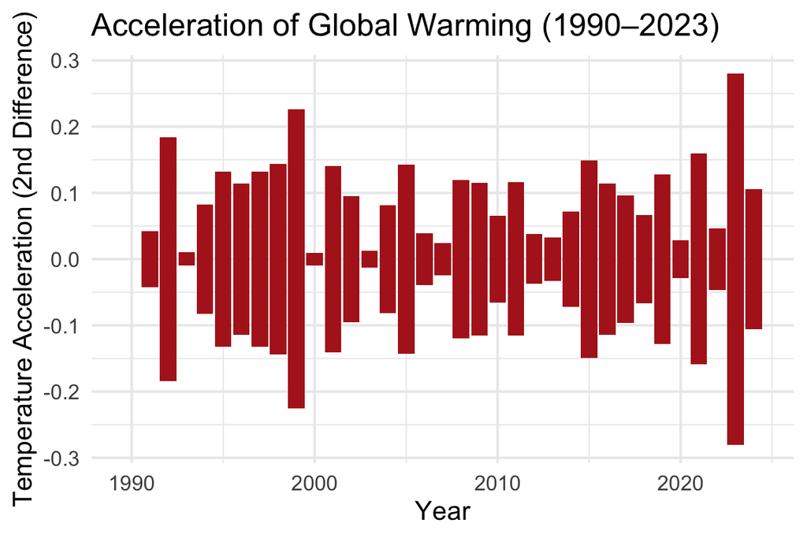

```r
combined$accel <- combined$temp_anomaly -
  2 * dplyr::lag(combined$temp_anomaly, 1) +
  dplyr::lag(combined$temp_anomaly, 2)

ggplot(combined, aes(year, accel)) +
  geom_col(fill = "firebrick") +
  labs(
    title = "Acceleration of Global Warming (1990–2023)",
    y = "Temperature Acceleration (2nd Difference)",
    x = "Year"
  ) +
  theme_minimal(base_size = 14)
```

#### 3.0.0.6 3.6 Time-Series Decomposition (STL)

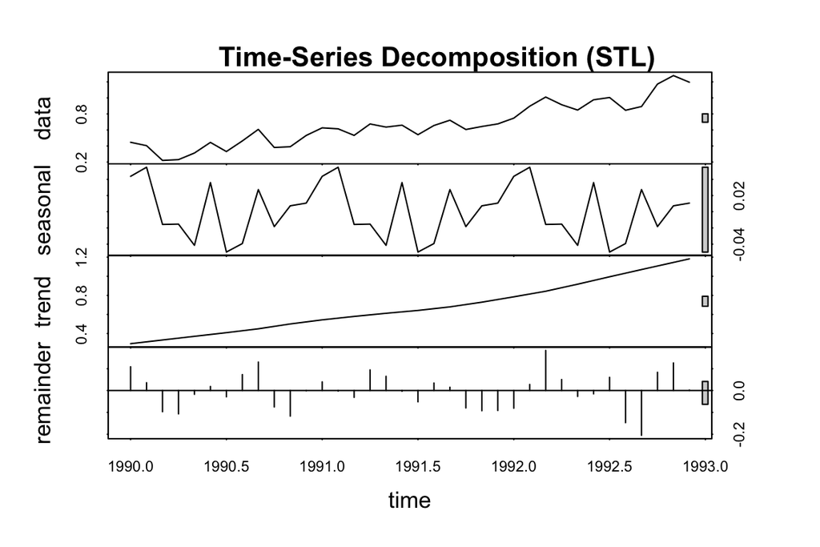

```r
gistem_annual <- readRDS("data/gistem_annual.rds")
ts_temp <- ts(gistem_annual$temp_anomaly, start = 1990, frequency = 12)
stl_temp <- stl(ts_temp, s.window = "periodic")

plot(stl_temp)
title("Time-Series Decomposition (STL)")
```

The STL decomposition breaks the temperature-anomaly time series into three components: trend, seasonality, and remainder. The trend component shows a smooth and steady upward trajectory, confirming long-term global warming independent of short-term fluctuations. The seasonal component captures recurring intra-annual variations, which are relatively small given that the anomalies represent averaged annual values. The remainder component reflects irregular deviations, which correspond to volcanic events, El Niño cycles, or measurement variability. Together, the decomposition provides strong evidence that the warming pattern is structurally embedded over time, with a persistent upward trend dominating the series.

#### 3.0.0.7 3.7 Parallel Coordinate Plot – Top CO₂ Emitters

```r
# Country-level averages over the whole study period

pc_data <- combined

pc_data <- dplyr::group_by(pc_data, country)

pc_data <- dplyr::summarise(
  pc_data,
  co2                    = mean(co2, na.rm = TRUE),
  gdp_per_capita         = mean(gdp_per_capita, na.rm = TRUE),
  renewable_energy_share = mean(renewable_energy_share, na.rm = TRUE),
  temp_anomaly           = mean(temp_anomaly, na.rm = TRUE),
  .groups = "drop"
)

pc_data <- tidyr::drop_na(pc_data)

pc_data <- pc_data[order(pc_data$co2, decreasing = TRUE), ]  # highest emitters first

# Take top 15 emitters (or fewer if you don't have that many)
top_emitters <- pc_data[1:min(15, nrow(pc_data)), ]
top_emitters <- as.data.frame(top_emitters)
top_emitters$country <- as.factor(top_emitters$country)

nrow(top_emitters)   # just to check
```

```
[1] 15
```

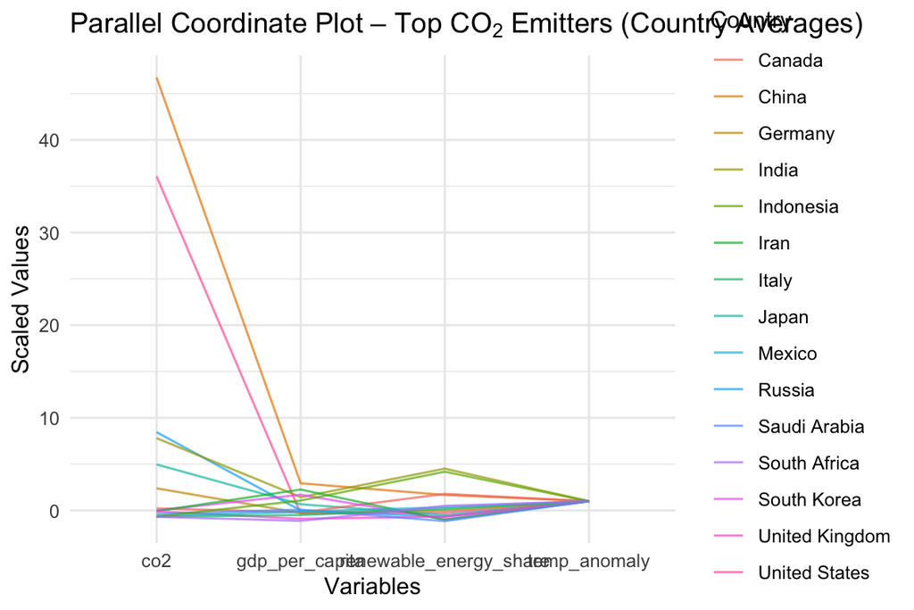

```r
if (nrow(top_emitters) >= 2) {
  ggparcoord(
    data        = top_emitters,
    columns     = 2:5,      # co2, gdp_per_capita, renewables, temp
    groupColumn = 1,        # color by country
    scale       = "robust",
    alphaLines  = 0.7
  ) +
    theme_minimal() +
    labs(
      title = expression("Parallel Coordinate Plot – Top " * CO[2] * " Emitters (Country Averages)"),
      x     = "Variables",
      y     = "Scaled Values",
      color = "Country"
    )
} else {
  message("Not enough rows in top_emitters to draw a parallel coordinate plot.")
}
```

The parallel coordinate plot compares the top CO₂-emitting countries across four metrics: CO₂ emissions, GDP per capita, renewable-energy share, and average temperature anomaly. The plot highlights stark contrasts between countries. Nations like China and the United States dominate the CO₂ axis, reflecting their overwhelming contribution to global emissions. Meanwhile, several high emitters—such as Russia or Saudi Arabia—show low renewable-energy shares, indicating carbon-intensive energy systems. Interestingly, temperature anomalies remain relatively clustered across countries because global anomalies apply uniformly. The plot visually reinforces how diverse economic structures, energy practices, and national policies contribute to emissions differences among the highest-emitting nations.

#### 3.0.0.8 3.8 Interactive Parallel Coordinate Plot (Plotly)

```r
if (nrow(top_emitters) >= 2) {
  plot_ly(
    type = "parcoords",
    line = list(
      color     = top_emitters$co2,
      colorscale = "Viridis"
    ),
    dimensions = list(
      list(label = "CO₂",                  values = top_emitters$co2),
      list(label = "GDP per capita",       values = top_emitters$gdp_per_capita),
      list(label = "Renewables share",     values = top_emitters$renewable_energy_share),
      list(label = "Temp anomaly",         values = top_emitters$temp_anomaly)
    )
  )
}
```

[interactive chart not shown]

The interactive version of the parallel coordinate plot allows dynamic exploration of the same relationships. Users can hover over lines to identify specific countries and compare their metric values more precisely. This version is especially useful for distinguishing between countries that appear visually similar in the static plot and for understanding how renewable-energy adoption interacts with GDP and emissions among top emitters. It enhances interpretability by offering a multidimensional perspective on emissions drivers.

#### 3.0.0.9 3.9 Global CO₂ Choropleth Map

```r
# 1) Pick the latest year in your dataset
latest_year <- max(combined$year, na.rm = TRUE)

# 2) Aggregate CO2 per country for that year
co2_latest <- combined[combined$year == latest_year, ]

co2_latest <- dplyr::group_by(co2_latest, iso_code, country)

co2_latest <- dplyr::summarise(
  co2_latest,
  co2 = sum(co2, na.rm = TRUE),
  .groups = "drop"
)

# 3) World polygons (sf object)
world <- ne_countries(scale = "medium", returnclass = "sf")

# 4) Join emissions onto the world map
world_co2 <- dplyr::left_join(
  world,
  co2_latest,
  by = c("iso_a3" = "iso_code")
)

world_co2 <- world_co2[!is.na(world_co2$co2) & world_co2$co2 > 0, ]
```

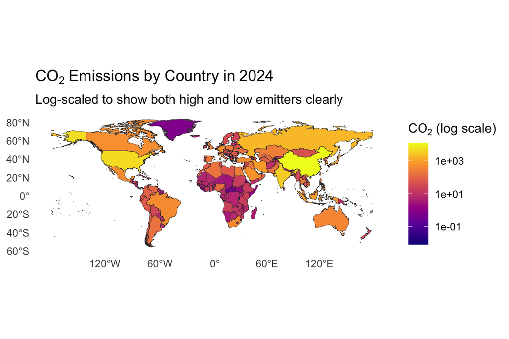

```r
choropleth_co2 <- ggplot(world_co2) +
  geom_sf(aes(fill = co2), color = "grey20", size = 0.1) +
scale_fill_viridis_c(
  option = "plasma",
  trans  = "log10",
  na.value = "grey90",
  name = expression(CO[2] * " (log scale)")
) +
labs(
  title = bquote(CO[2] ~ "Emissions by Country in" ~ .(latest_year)),
  subtitle = "Log-scaled to show both high and low emitters clearly",
  x = NULL,
  y = NULL
) +
  theme_minimal() +
  theme(
    legend.position = "right",
    panel.grid = element_blank()
  )


choropleth_co2
```

#### 3.0.0.10 3.10 Two-Panel Map: Who Produces CO₂ vs Who Suffers Warming?

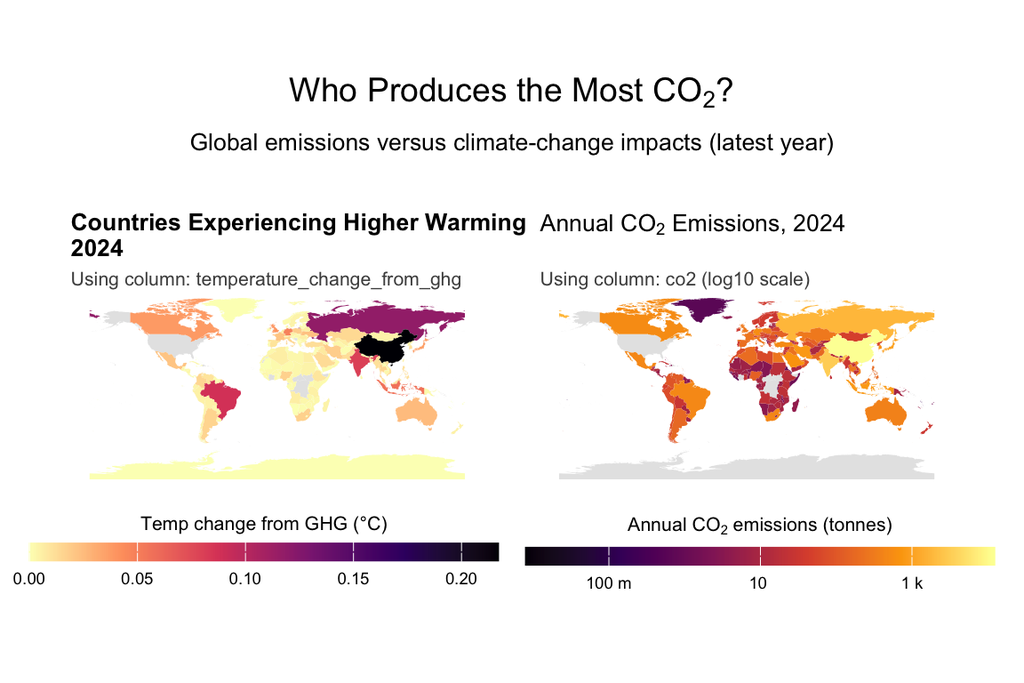

```r
# Load world map
world_sf <- rnaturalearth::ne_countries(scale = "medium", returnclass = "sf")

# Latest year
latest_year <- max(combined$year, na.rm = TRUE)

# Temperature impact column candidates
temp_candidates <- c(
  "temperature_change_from_ghg",
  "temperature_change_from_co2",
  "temperature_change_from_ch4",
  "temperature_change_from_n2o"
)
temp_col <- temp_candidates[temp_candidates %in% names(combined)][1]
if (is.na(temp_col)) stop("No temperature-change column found.")

# CO2 column candidates
co2_candidates <- c(
  "co2",
  "co2_including_luc",
  "consumption_co2",
  "cement_co2",
  "coal_co2",
  "oil_co2",
  "gas_co2",
  "flaring_co2"
)
co2_col <- co2_candidates[co2_candidates %in% names(combined)][1]
if (is.na(co2_col)) stop("No CO2 column found.")

# Country column
country_candidates <- c("country", "country_name")
country_col <- country_candidates[country_candidates %in% names(combined)][1]
if (is.na(country_col)) stop("No country column found.")

# Prepare latest-year country data
latest_df <- combined |>
  dplyr::filter(year == latest_year) |>
  dplyr::transmute(
    country_join = .data[[country_col]],
    temp_impact  = .data[[temp_col]],
    co2_total    = .data[[co2_col]]
  ) |>
  dplyr::group_by(country_join) |>
  dplyr::summarise(
    temp_impact = mean(temp_impact, na.rm = TRUE),
    co2_total   = mean(co2_total, na.rm = TRUE),
    .groups = "drop"
  )

# Join with world map
world_joined <- dplyr::left_join(world_sf, latest_df, by = c("name" = "country_join"))

# Remove invalid values for log scale
world_joined$co2_total[!is.finite(world_joined$co2_total) | world_joined$co2_total <= 0] <- NA

# Legend guide
legend_bar <- guide_colorbar(
  title.position = "top",
  title.hjust    = 0.5,
  barwidth       = unit(7, "cm"),     # <- was 9cm (too wide in HTML)
  barheight      = unit(0.28, "cm")
)

# Common theme
common_theme <- theme_void(base_size = 9) +
  theme(
    legend.position      = "bottom",
    legend.direction     = "horizontal",
    legend.box           = "vertical",
    legend.justification = "center",

    legend.box.margin    = ggplot2::margin(t = 2, r = 8, b = 0, l = 8),

    legend.title         = element_text(size = 8),
    legend.text          = element_text(size = 7),

    plot.title           = element_text(size = 10, face = "bold", hjust = 0),
    plot.subtitle        = element_text(size = 8, colour = "grey30", hjust = 0),

    # give each panel more breathing room
    plot.margin          = ggplot2::margin(6, 12, 6, 12)
  )

# Map 1: temperature impacts
map_impact <- ggplot(world_joined) +
  geom_sf(aes(fill = temp_impact), color = NA) +
  scale_fill_viridis_c(
    option    = "magma",
    direction = -1,
    na.value  = "grey90",
    name      = "Temp change from GHG (°C)",
    labels    = scales::label_number(accuracy = 0.01),
    guide     = legend_bar
  ) +
  labs(
    title = paste0("Countries Experiencing Higher Warming\n", latest_year),
    subtitle = paste0("Using column: ", temp_col)
  ) +
  common_theme

# Map 2: CO2 emissions
map_co2 <- ggplot(world_joined) +
  geom_sf(aes(fill = co2_total), color = NA) +
  scale_fill_viridis_c(
    option   = "inferno",
    trans    = "log10",
    na.value = "grey90",
    name     = expression("Annual " * CO[2] * " emissions (tonnes)"),
    labels   = scales::label_number(scale_cut = scales::cut_si("")),
    guide    = legend_bar
  ) +
  labs(
    title = bquote("Annual " * CO[2] * " Emissions, " * .(latest_year)),
    subtitle = paste0("Using column: ", co2_col, " (log10 scale)")
  ) +
  common_theme

# Combine maps + collect legends
final_maps <- (map_impact | map_co2) +
  plot_layout(guides = "collect") +
  plot_annotation(
    title    = expression("Who Produces the Most " * CO[2] * "?"),
    subtitle = "Global emissions versus climate-change impacts (latest year)",
    theme = theme(
      plot.title = element_text(
        size = 14, face = "bold", hjust = 0.5,
        margin = ggplot2::margin(b = 8)
      ),
      plot.subtitle = element_text(
        size = 10, hjust = 0.5,
        margin = ggplot2::margin(b = 14)
      ),
      # IMPORTANT: extra left/right padding at the whole-figure level
      plot.margin = ggplot2::margin(10, 18, 10, 18)
    )
  ) &
  theme(legend.position = "bottom")

final_maps
```

#### 3.0.0.11 3.11 Global CO₂, Temperature Anomaly, and Renewable Energy Index (1990–2023)

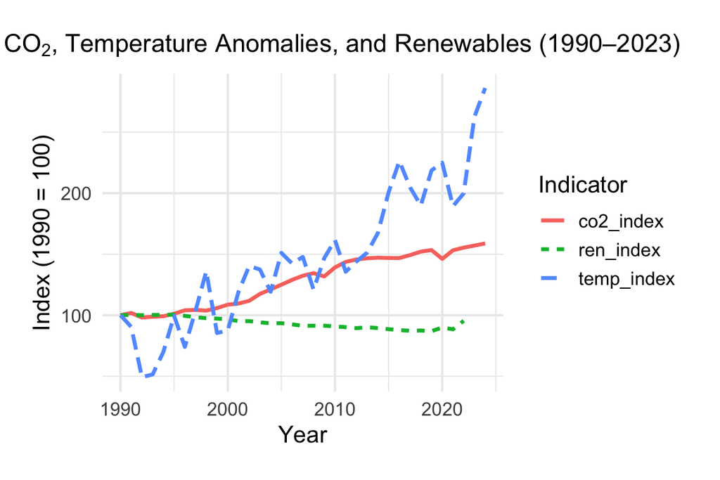

```r
# Compute global time series
global_ts <- dplyr::group_by(combined, year)

global_ts <- dplyr::summarize(
  global_ts,
  temp_anomaly_global = mean(temp_anomaly, na.rm = TRUE),
  co2_global          = sum(co2, na.rm = TRUE),
  renewables_global   = mean(renewable_energy_share, na.rm = TRUE)
)

# Normalize to 1990 = 100
base_year <- 1990
base_vals <- global_ts[global_ts$year == base_year, ]

global_ts_norm <- global_ts
global_ts_norm$temp_index <- 100 * global_ts_norm$temp_anomaly_global / base_vals$temp_anomaly_global
global_ts_norm$co2_index  <- 100 * global_ts_norm$co2_global / base_vals$co2_global
global_ts_norm$ren_index  <- 100 * global_ts_norm$renewables_global / base_vals$renewables_global

# Convert to long format (no pipes)
global_ts_long <- tidyr::pivot_longer(
  global_ts_norm[, c("year", "temp_index", "co2_index", "ren_index")],
  cols = -year,
  names_to = "indicator",
  values_to = "value"
)

# Remove NA / Inf values
global_ts_long_clean <- global_ts_long[
  is.finite(global_ts_long$value) & !is.na(global_ts_long$value),
]

# Plot
ggplot(
  global_ts_long_clean,
  aes(x = year, y = value, color = indicator, linetype = indicator)
) +
  geom_line(size = 1.1) +
  labs(
    title = expression("Global " * CO[2] * ", Temperature Anomalies, and Renewables (1990–2023)"),
    x = "Year",
    y = "Index (1990 = 100)",
    color = "Indicator",
    linetype = "Indicator"
  ) +
  theme_minimal(base_size = 14) +
  theme(
    plot.title  = element_text(size = 15, hjust = 0.5, face = "bold"),
    plot.margin = ggplot2::margin(t = 20, r = 20, b = 20, l = 20)
  )
```

This indexed comparison plot normalizes CO₂ emissions, temperature anomalies, and renewable energy share to a common baseline of 1990 = 100. Indexing allows us to compare growth rates across variables that otherwise have different units. The graph shows that global CO₂ emissions have risen steadily since 1990, increasing by more than 50% over the study period. Temperature anomalies, however, rise even more sharply than CO₂, indicating that warming is accelerating relative to emissions. In contrast, the indexed renewable energy share remains almost flat for most of the period, even declining slightly until the early 2010s. Only in the last few years does it show a modest upward movement. The combination of rising emissions, accelerating warming, and stagnant renewable adoption highlights the global imbalance between fossil-fuel use and clean-energy transitions. This visualization sets the stage for understanding why global temperatures continue to rise despite policy discussions around sustainability

#### 3.0.0.12 3.12 Global Temperature Anomaly Over Time (1990–2023)

```r
plot_obj <- plot_ly(
  data = combined,
  x = ~year,
  y = ~temp_anomaly,
  type = "scatter",
  mode = "lines+markers",
  line = list(color = "firebrick", width = 3),
  marker = list(size = 6)
)

plot_obj <- layout(
  plot_obj,
  title = "Global Temperature Anomaly (1990–2023)",
  xaxis = list(title = "Year"),
  yaxis = list(title = "Temperature Anomaly (°C)")
)

plot_obj
```

[interactive chart not shown]

This time-series plot isolates global temperature anomalies to show how warming has evolved from 1990 to 2023. The line clearly reveals a persistent upward trajectory, moving from roughly 0.25°C above the baseline in the early 1990s to more than 1.25°C in 2023. Although the curve has short-term fluctuations—caused by natural climatic variations such as El Niño, volcanic activity, or ocean heat exchanges—the long-run trend is unmistakably upward. Especially after 2010, the anomalies begin rising more steeply, reflecting recent years of record-breaking temperatures. The graph provides foundational evidence that climate change is not theoretical or cyclical but a long-term warming trend aligned with rising anthropogenic emissions.

#### 3.0.0.13 3.13 Global CO₂ Emissions Over Time (1990–2023)

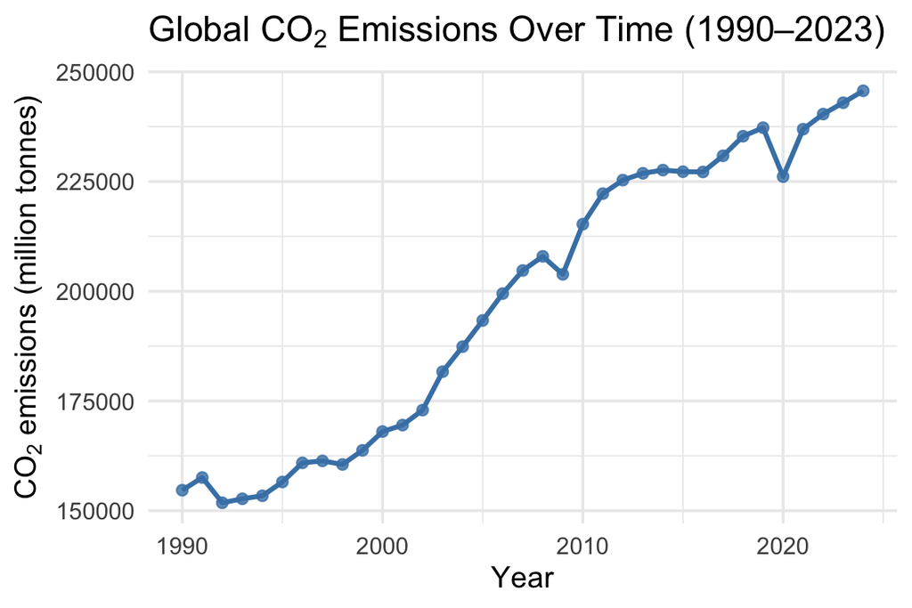

```r
# Compute global CO2 time series
co2_ts <- combined[is.finite(combined$co2), ]

co2_ts <- dplyr::group_by(co2_ts, year)

co2_ts <- dplyr::summarize(
  co2_ts,
  co2_global = sum(co2, na.rm = TRUE)
)

# Plot
ggplot(co2_ts, aes(x = year, y = co2_global)) +
  geom_line(color = "steelblue", linewidth = 1.1) +
  geom_point(color = "steelblue", alpha = 0.8, size = 2) +
  labs(
    title = expression("Global " * CO[2] * " Emissions Over Time (1990–2023)"),
    x = "Year",
    y = expression(CO[2] * " emissions (million tonnes)")
  ) +
  theme_minimal(base_size = 14)
```

This graph shows total global CO₂ emissions aggregated annually. The steady and almost uninterrupted growth from roughly 150,000 million tonnes in 1990 to over 240,000 million tonnes in 2023 highlights the sustained dependence on fossil fuels. Periods of plateau or slight decline—such as around 2008 (global financial crisis) and 2020 (COVID-19 disruptions)—are brief and quickly return to the upward trajectory. This confirms that emissions reductions have not yet been structural or durable at the global level. The long-term growth in emissions corresponds closely with GDP expansion, industrialization in emerging economies, and increased global energy demand.

#### 3.0.0.14 3.14 Global Renewable Energy Share Over Time (1990–2023)

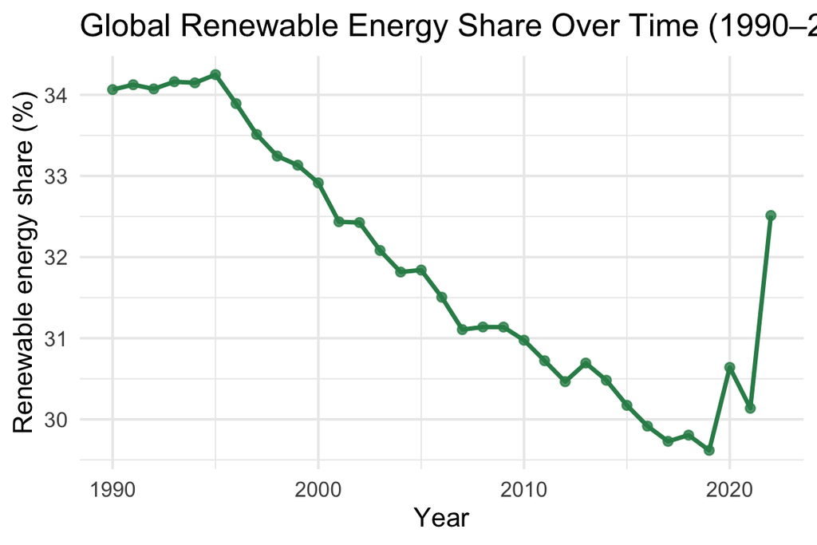

```r
# Compute global renewable energy time series
renew_ts <- combined[is.finite(combined$renewable_energy_share), ]

renew_ts <- dplyr::group_by(renew_ts, year)

renew_ts <- dplyr::summarize(
  renew_ts,
  renewables_global = mean(renewable_energy_share, na.rm = TRUE)
)

# Plot
ggplot(renew_ts, aes(x = year, y = renewables_global)) +
  geom_line(color = "seagreen4", linewidth = 1.1) +
  geom_point(color = "seagreen4", alpha = 0.8) +
  labs(
    title = "Global Renewable Energy Share Over Time (1990–2023)",
    x = "Year",
    y = "Renewable energy share (%)"
  ) +
  theme_minimal(base_size = 14)
```

This graph displays the global share of renewables in primary energy consumption. Surprisingly, instead of increasing over the decades, the renewable share declines from above 34% in the early 1990s to below 30% around 2018. The decline is not because renewables decreased, but because fossil-fuel consumption grew at a much faster rate. Only very recently—around 2021 onward—do we observe a notable jump in renewable adoption, reflecting accelerated investments in solar, wind, and hydro capacity. However, this late surge is still insufficient compared to the scale of CO₂ emissions growth shown earlier. The graph highlights the structural lag between recognizing climate change and implementing large-scale energy transformation.

## 3.1 4. Multivariate Structure: PCA & Clustering

#### 3.1.0.1 4.1 Principal Component Analysis (PCA)

##### 3.1.0.1.1 4.1.1 Variance Explained by Principal Components (Scree Plot)

```r
# Build PCA data with a consistent population name (no pipes)

pca_data <- combined

# Rename population.x -> population
pca_data <- dplyr::rename(
  pca_data,
  population = population.x
)

# Select required columns
pca_data <- pca_data[
  , c("country", "year", "co2", "gdp_per_capita", "population", "renewable_energy_share")
]

# Drop rows with missing values in key variables
pca_data <- tidyr::drop_na(
  pca_data,
  co2,
  gdp_per_capita,
  population,
  renewable_energy_share
)

# Run PCA on numeric variables (no pipes)
pca_model <- prcomp(
  pca_data[, c("co2", "gdp_per_capita", "population", "renewable_energy_share")],
  scale. = TRUE
)

summary(pca_model)
```

```
Importance of components:
                          PC1    PC2    PC3     PC4
Standard deviation     1.3441 1.0558 0.9017 0.51545
Proportion of Variance 0.4517 0.2787 0.2032 0.06642
Cumulative Proportion  0.4517 0.7303 0.9336 1.00000
```

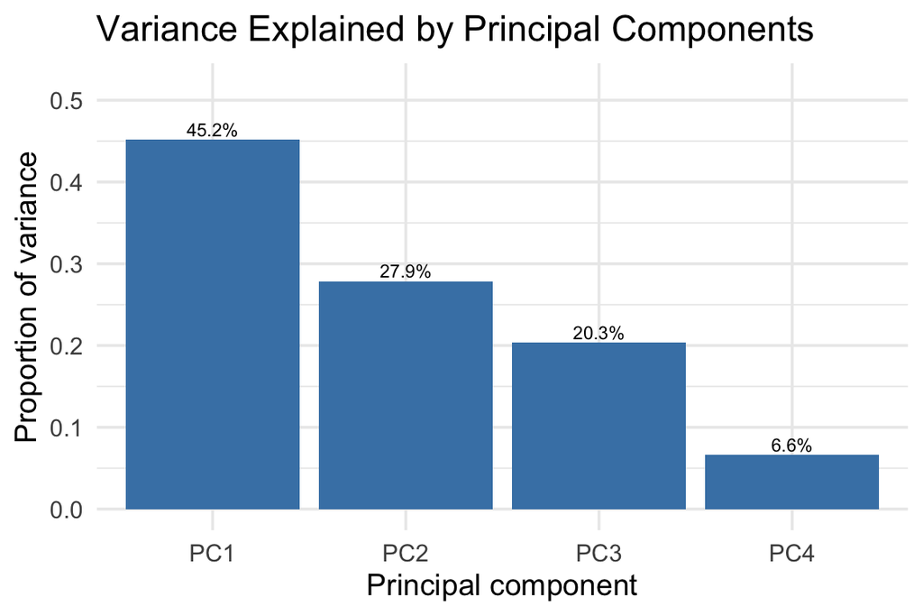

```r
eig_vals <- pca_model$sdev^2
prop_var <- eig_vals / sum(eig_vals)

scree_df <- data.frame(
  PC  = paste0("PC", seq_along(prop_var)),
  var = prop_var
)

ggplot(scree_df, aes(x = PC, y = var)) +
  geom_col(fill = "steelblue") +
  geom_text(aes(label = scales::percent(var, accuracy = 0.1)),
            vjust = -0.3, size = 3) +
  labs(
    title = "Variance Explained by Principal Components",
    x = "Principal component",
    y = "Proportion of variance"
  ) +
  ylim(0, max(scree_df$var) * 1.15) +
  theme_minimal(base_size = 14)
```

##### 3.1.0.1.2 4.1.2 PCA Loadings Plot (PC1 vs PC2)

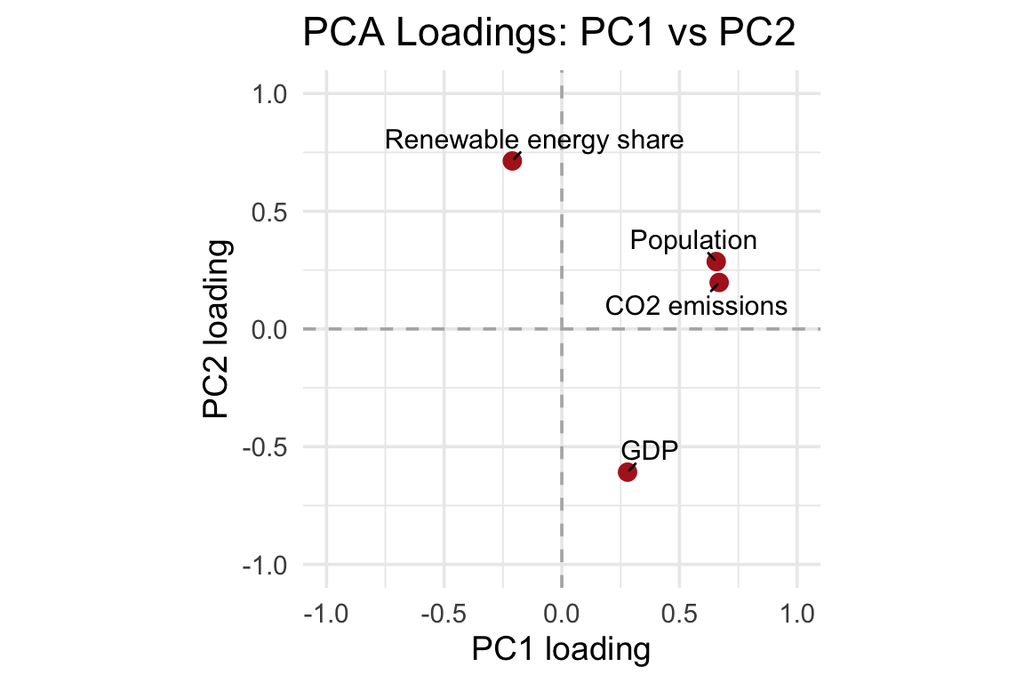

```r
# Rebuild loadings with clean labels
loadings <- as.data.frame(pca_model$rotation[, 1:2])
colnames(loadings)[1:2] <- c("PC1", "PC2")

loadings$variable <- c(
  "CO2 emissions",
  "GDP",
  "Population",
  "Renewable energy share"
)

ggplot(loadings, aes(x = PC1, y = PC2, label = variable)) +
  geom_hline(yintercept = 0, linetype = "dashed", color = "grey70") +
  geom_vline(xintercept = 0, linetype = "dashed", color = "grey70") +
  geom_point(color = "firebrick", size = 3) +
  geom_text_repel(size = 4, box.padding = 0.3, min.segment.length = 0) +
  coord_equal(xlim = c(-1, 1), ylim = c(-1, 1)) +
  labs(
    title = "PCA Loadings: PC1 vs PC2",
    x = "PC1 loading",
    y = "PC2 loading"
  ) +
  theme_minimal(base_size = 14)
```

The loadings plot shows how each original variable contributes to PC1 and PC2. CO₂ emissions, GDP per capita, and population all load positively on PC1, indicating that this first component represents a general “economic scale and emissions intensity” axis—countries with higher economic output and large populations also emit more CO₂. Renewable energy share, however, loads strongly on PC2 and in the opposite direction to GDP, suggesting that PC2 represents a “clean-energy versus economic dependency on fossil fuels” axis. Countries with high renewable penetration score high on PC2, while those with fossil-fuel-heavy growth score lower. This separation provides an intuitive interpretation of the PCA structure: PC1 differentiates countries by size/emissions, while PC2 differentiates by energy strategy.

#### 3.1.0.2 4.2 K-Means Clustering

##### 3.1.0.2.1 4.2.1 Elbow Plot for Optimal Cluster Selection

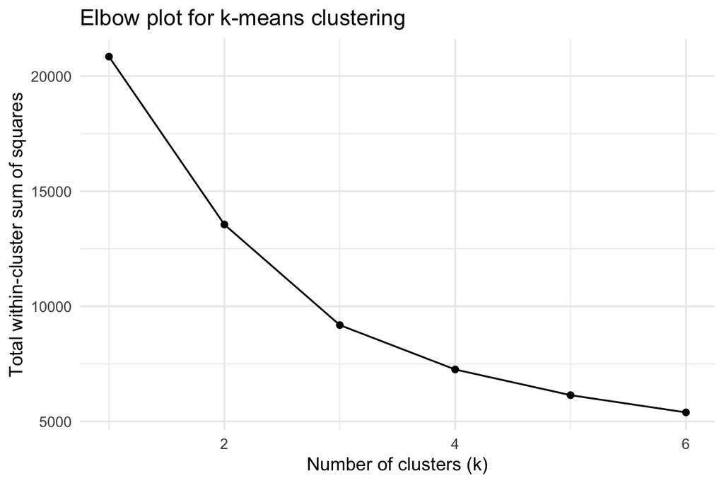

```r
set.seed(123)

# Select PCA inputs
pca_inputs <- pca_data[, c("co2", "gdp_per_capita", "population", "renewable_energy_share")]

# Scale inputs
pca_inputs <- scale(pca_inputs)

# Compute within-cluster sum of squares for different k
wss <- purrr::map_dbl(
  1:6,
  function(k) {
    kmeans(pca_inputs, centers = k, nstart = 20)$tot.withinss
  }
)

# Plot elbow curve
qplot(1:6, wss, geom = "line") +
  geom_point() +
  labs(
    x = "Number of clusters (k)",
    y = "Total within-cluster sum of squares",
    title = "Elbow plot for k-means clustering"
  ) +
  theme_minimal()
```

The elbow curve presents the total within-cluster sum of squares across k = 1 to 6 clusters. There is a clear and abrupt decline from k = 1 to k = 3, after which the curve begins to flatten. This “elbow” occurs around k = 3, suggesting that using three clusters best balances model simplicity and internal cohesion. Beyond this point, additional clusters produce diminishing returns and would over-segment the data without meaningful improvement in cluster structure.

##### 3.1.0.2.2 4.2.2 Country–Year Clusters in PCA Space (PC1–PC2 Scatter)

```r
# PC scores (same rows as pca_data)
pca_scores <- as.data.frame(pca_model$x[, 1:2])  # PC1 & PC2
names(pca_scores) <- c("PC1", "PC2")

# Attach country + year
pca_scores$country <- pca_data$country
pca_scores$year    <- pca_data$year


set.seed(123)
k <- 3  # or 4, based on your elbow plot

km_model <- kmeans(
  pca_scores[, c("PC1", "PC2")],
  centers = k,
  nstart = 50
)

# Add cluster labels
pca_scores$cluster <- factor(km_model$cluster)

# Also keep cluster info attached to the original PCA data
pca_data_clustered <- pca_data
pca_data_clustered$cluster <- factor(km_model$cluster)
```

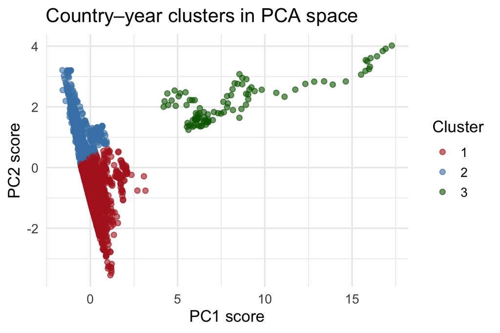

```r
ggplot(pca_scores, aes(x = PC1, y = PC2, color = cluster)) +
  geom_point(alpha = 0.6, size = 1.8) +
  labs(
    title  = "Country–year clusters in PCA space",
    x      = "PC1 score",
    y      = "PC2 score",
    color  = "Cluster"
  ) +
  theme_minimal(base_size = 14) +
  scale_color_manual(values = c("firebrick", "steelblue", "darkgreen"))
```

Plotting the k-means results in the reduced PCA space reveals three distinct and interpretable clusters. Cluster 1 (Red) groups the majority of countries with low CO₂ emissions, moderate population sizes, and modest GDP levels. These economies tend to emit less and rely more heavily on traditional energy mixes. Cluster 2 (Blue) contains countries with high renewable energy shares relative to their GDP and emissions, typically reflecting smaller economies or countries with strong renewable policies. Cluster 3 (Green) is sparse but highly distinct, representing large, high-emitting economies with massive populations, such as China and India. These countries dominate global emission totals and form a unique structural block. The separation of clusters along PC1 reflects differences in economic scale and emissions, while separation along PC2 highlights renewable energy adoption. The clear spacing confirms that the PCA structure captures meaningful global patterns and that clustering within this reduced space is appropriate.

```r
# Cluster summary
cluster_summary <- dplyr::group_by(pca_data_clustered, cluster)

cluster_summary <- dplyr::summarize(
  cluster_summary,
  n_rows    = dplyr::n(),                 # number of country-year observations
  avg_co2   = mean(co2, na.rm = TRUE),
  avg_gdp   = mean(gdp_per_capita, na.rm = TRUE),
  avg_pop   = mean(population, na.rm = TRUE),
  avg_renew = mean(renewable_energy_share, na.rm = TRUE)
)

cluster_summary
```

```
# A tibble: 3 × 6
  cluster n_rows avg_co2 avg_gdp    avg_pop avg_renew
  <fct>    <int>   <dbl>   <dbl>      <dbl>     <dbl>
1 1         3384   128.     26.4  21798044.      16.2
2 2         1732    18.3    18.1  21554253.      65.8
3 3           96  4502.     31.2 921087464.      23.3
```

## 3.2 5. Modeling: Regression, Trees, and Random Forests

```r
# Identify population column(s)
pop_candidates <- intersect(
  c("population", "population.x", "population.y"),
  names(combined)
)

# Choose the one with the fewest missing values
pop_col <- pop_candidates[
  which.min(sapply(pop_candidates, function(x) sum(is.na(combined[[x]]))))
]

cat("Using population column:", pop_col, "\n")
```

```
Using population column: population.x
```

```r
# Build model data
model_data <- combined

# Create transformed variables
model_data$population_clean <- model_data[[pop_col]]
model_data$log_co2 <- log(model_data$co2 + 1)
model_data$log_gdp <- log(model_data$gdp + 1)
model_data$log_pop <- log(model_data$population_clean + 1)

# Select required columns
model_data <- model_data[
  , c(
    "country", "year",
    "temp_anomaly",
    "log_co2", "log_gdp", "log_pop",
    "renewable_energy_share"
  )
]

# Drop rows with missing values
model_data <- tidyr::drop_na(model_data)
```

```r
set.seed(123)

n <- nrow(model_data)
train_idx <- sample(seq_len(n), size = floor(0.7 * n))

train <- model_data[train_idx, ]
test  <- model_data[-train_idx, ]
```

```r
rf_model <- randomForest(
  temp_anomaly ~ log_co2 + log_gdp + log_pop + renewable_energy_share,
  data = train,
  ntree = 500,
  mtry = 2,
  importance = TRUE
)

rf_model
```

```
Call:
 randomForest(formula = temp_anomaly ~ log_co2 + log_gdp + log_pop +      renewable_energy_share, data = train, ntree = 500, mtry = 2,      importance = TRUE)
               Type of random forest: regression
                     Number of trees: 500
No. of variables tried at each split: 2

          Mean of squared residuals: 0.01658668
                    % Var explained: 64.48
```

```r
rf_pred <- predict(rf_model, newdata = test)

rf_rmse <- rmse(test$temp_anomaly, rf_pred)
rf_rmse
```

```
[1] 0.1271487
```

#### 3.2.0.1 5.1 Random Forest Variable Importance

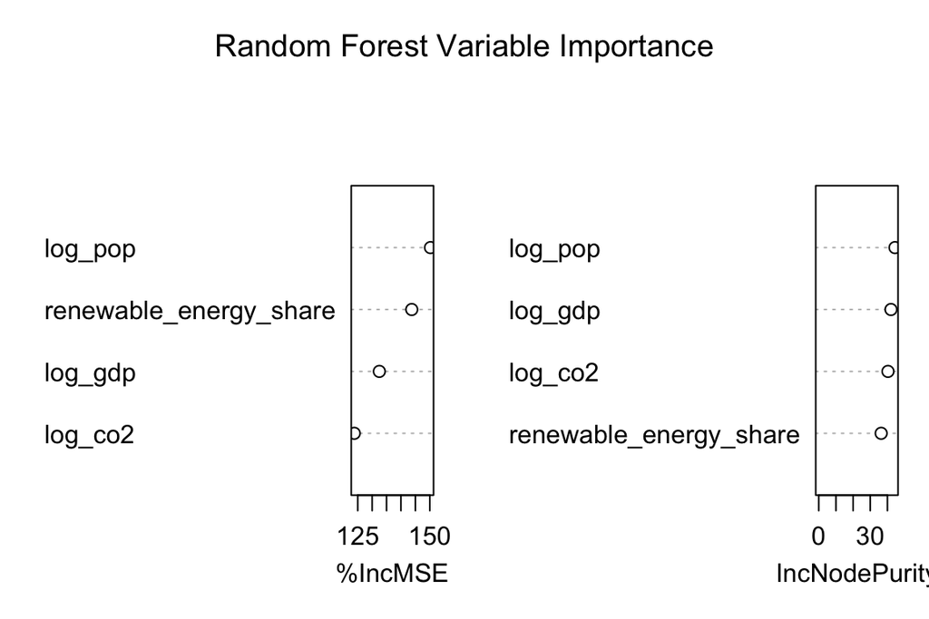

```r
varImpPlot(rf_model, main = "Random Forest Variable Importance")
```

The Random Forest importance plot shows that population size (log_pop) is the most influential driver of temperature anomaly predictions. This makes intuitive sense: larger populations tend to correlate with higher total energy demand, greater industrial activity, and ultimately more emissions. Renewable-energy share emerges as the next meaningful contributor, suggesting that differences in clean-energy adoption significantly affect warming outcomes across countries. GDP and CO₂ emissions also play important roles, but their importance is partially absorbed by population effects due to strong correlations in national growth patterns. Overall, the model highlights that structural socio-economic characteristics—how big a country is and how it sources its energy—shape global temperature patterns more powerfully than individual yearly fluctuations.